# exam220408

## Exam 2022-04-08

### Starting with the NIR data of bird feathers

In the reflection dataset we will look at what specific NIR reflection patterns are in what color feather.

```python
# load dependencies
import pandas as pd
import matplotlib.pyplot as plt
import matplotlib.patches as mpatches
import numpy as np
plt.style.use('dark_background')
%matplotlib inline
```

```python
# load file into DataFrame
nir_feather_file = "reflectance and transmission spec measurements(1).xlsx"
nir_df = pd.read_excel(nir_feather_file, sheet_name="Reflectance")

# transpose the file to wavelengths in column and samples in rows
nir_df = nir_df.set_index("wavelength").T.sort_index()
nir_df["Colour"] = [sample.split('_')[0][-1] for sample in nir_df.index]
nir_df.info()
```

```
<class 'pandas.core.frame.DataFrame'>
Index: 438 entries, AacuW_B_Splice17_1.txt to TmigW_W_Splice17_3.txt
Columns: 902 entries, 300 to Colour
dtypes: float64(901), object(1)
memory usage: 3.0+ MB
```

```python
# How many, and what categories are there?
set_sample = set(sample.split('_')[0] for sample in nir_df.index)
print(len(nir_df.index))
print(len(set_sample))
#lets rid the background acrylic samples
nir_df = nir_df.drop([sample for sample in nir_df.index if 'background' in sample])
print(len(nir_df.index))
```

```
438
74
432
```

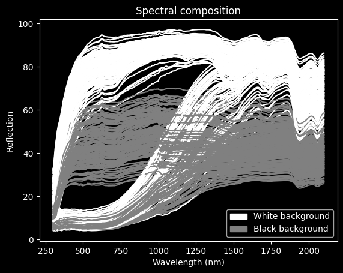

```python
#Plotting the feather wavelengths, also looking at the effect of the backgrounds used

def plot_spect_df(df):
    for sample, index in zip(df.values,df.index):
        if index.split('_')[1] == 'B':
            c = 'grey'
        else:
            c = 'white'
        plt.plot(df.columns, sample, color=c)
    plt.title("Spectral composition")
    plt.xlabel("Wavelength (nm)")
    plt.ylabel("Reflection")
    white_patch = mpatches.Patch(color='white', label='White background')
    black_patch = mpatches.Patch(color='grey', label='Black background')
    plt.legend(handles=[white_patch,black_patch])
    plt.show()

plot_spect_df(nir_df.iloc[:,:-1])
```

As seen in the plot, the strengths of the signals is quite different between the samples. It is quite clear that the white background reflect light better than black background. Some normalization needs to be done before extracting more spectral information from the data.

```python
from sklearn.preprocessing import MinMaxScaler
from sklearn.preprocessing import StandardScaler

mms = MinMaxScaler(feature_range=(0,1))
stc = StandardScaler()

nir_norm_val = nir_df.iloc[:,:-1]
# Only use the NIR wavelengths 700- 2100
nir_norm_val = nir_norm_val.drop(columns=[column for column in nir_norm_val.columns if column < 700])
# Normalizing the spectrals (wavelength/sum(wavelengths))
nir_norm_val = nir_norm_val.subtract(nir_norm_val.mean(axis=1),axis=0)
nir_norm_val.iloc[:,:] = mms.fit_transform(nir_norm_val)# every value minimum of 0 maximum of 1
nir_norm_val.iloc[:,:] = stc.fit_transform(nir_norm_val)# every value average of 0 and stdev of 1

nir_norm_val.head(5)
```

| wavelength | 700 | 702 | 704 | 706 | 708 | 710 | 712 | 714 | 716 | 718 | ... | 2082 | 2084 | 2086 | 2088 | 2090 | 2092 | 2094 | 2096 | 2098 | 2100 |
| --- | --- | --- | --- | --- | --- | --- | --- | --- | --- | --- | --- | --- | --- | --- | --- | --- | --- | --- | --- | --- | --- |
| AacuW_B_Splice17_1.txt | 0.626719 | 0.626910 | 0.626223 | 0.624747 | 0.623456 | 0.623060 | 0.622795 | 0.622969 | 0.623101 | 0.623551 | ... | -0.366602 | -0.367016 | -0.367785 | -0.369285 | -0.369843 | -0.372009 | -0.373201 | -0.373551 | -0.372281 | -0.371261 |
| AacuW_B_Splice17_2.txt | 0.576175 | 0.576700 | 0.576645 | 0.576549 | 0.577115 | 0.578764 | 0.579574 | 0.580727 | 0.581791 | 0.581729 | ... | -0.467764 | -0.467978 | -0.468453 | -0.469272 | -0.469710 | -0.471677 | -0.473062 | -0.474956 | -0.476589 | -0.477248 |
| AacuW_B_Splice17_3.txt | 0.549161 | 0.549344 | 0.548905 | 0.548037 | 0.547463 | 0.547889 | 0.549053 | 0.550373 | 0.551244 | 0.551835 | ... | -0.422770 | -0.423123 | -0.423463 | -0.423634 | -0.423610 | -0.423708 | -0.423243 | -0.424248 | -0.424548 | -0.423870 |
| AacuW_W_Splice17_1.txt | 0.694297 | 0.696480 | 0.698383 | 0.700205 | 0.701243 | 0.701107 | 0.701525 | 0.701996 | 0.701929 | 0.702890 | ... | -1.703773 | -1.693236 | -1.688488 | -1.679717 | -1.675019 | -1.667842 | -1.661461 | -1.657319 | -1.653980 | -1.653306 |
| AacuW_W_Splice17_2.txt | 0.653516 | 0.655419 | 0.657049 | 0.659683 | 0.661852 | 0.662349 | 0.662636 | 0.663680 | 0.664830 | 0.666264 | ... | -1.674321 | -1.663575 | -1.658599 | -1.648901 | -1.643832 | -1.635797 | -1.629513 | -1.625255 | -1.623002 | -1.623760 |

5 rows × 701 columns

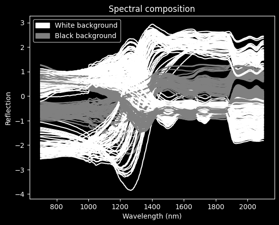

```python
plot_spect_df(nir_norm_val)
```

There is a clear separation between two groups, probably between lighter and darker feathers The approach will be spectral decomposition by PCA.

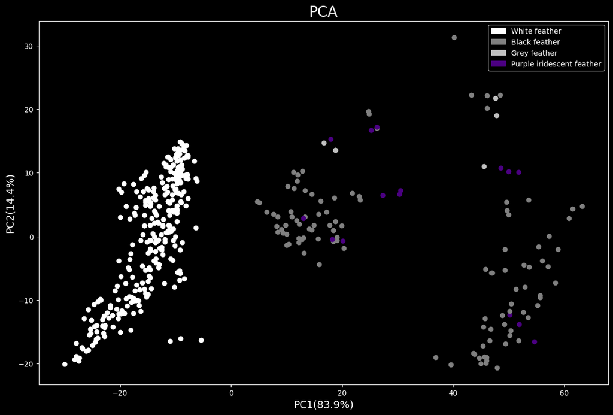

```python
from sklearn.decomposition import PCA
from matplotlib import colormaps as cm

color_dict = {'W':'white','B':'grey',
              'G':'silver', 'I':'indigo'}


data = nir_norm_val
colors = nir_df["Colour"].values


pca = PCA()
pca.fit(data)

pca.explained_variance_ratio_[:5]

PC1 = pca.fit_transform(data)[:,0]
PC2 = pca.fit_transform(data)[:,1]


fig, ax = plt.subplots(figsize=(14, 9))
for c,p1,p2 in zip(colors,PC1,PC2):
    col = color_dict[c]
    ax.scatter(p1, p2, color=col)
white_patch = mpatches.Patch(color='white', label='White feather')
black_patch = mpatches.Patch(color='grey', label='Black feather')
grey_patch = mpatches.Patch(color='silver', label='Grey feather')
purple_patch = mpatches.Patch(color='indigo', label='Purple iridescent feather')
ax.set_xlabel(f'PC1({pca.explained_variance_ratio_[0]*100:.3}%)', fontsize=14)
ax.set_ylabel(f'PC2({pca.explained_variance_ratio_[1]*100:.3}%)', fontsize=14)
ax.set_title('PCA', fontsize=20)
ax.legend(handles=[white_patch,black_patch,grey_patch,purple_patch])

plt.show()
```

As seen above in the PCA, one can clearly distinguish the near-infrared reflectance spectrum of white feathers compared to darker feathers. But there is also an interesting seperation between the two darker feather groups, with PCR it is possible to use PCA in combination with regression to regress features from the Excel with the first principle component as that explains the highest difference between the groups.

```python
#read in metadata
descr_df = pd.read_excel(nir_feather_file, sheet_name="Refl ReadMe")
descr_df = descr_df[["Down colour","Feather size","Body region"]]
descr_df = descr_df.dropna()
descr_df.head(5)
```

|  | Down colour | Feather size | Body region |
| --- | --- | --- | --- |
| 0 | white | large | abdomen |
| 1 | white | large | abdomen |
| 2 | grey | medium | breast |
| 3 | grey | medium | back |
| 4 | grey | medium | breast |

With this categorical data it is difficult to do regression, but maybe we can interpret it as a similarity plot? or something, idk you're the expert.

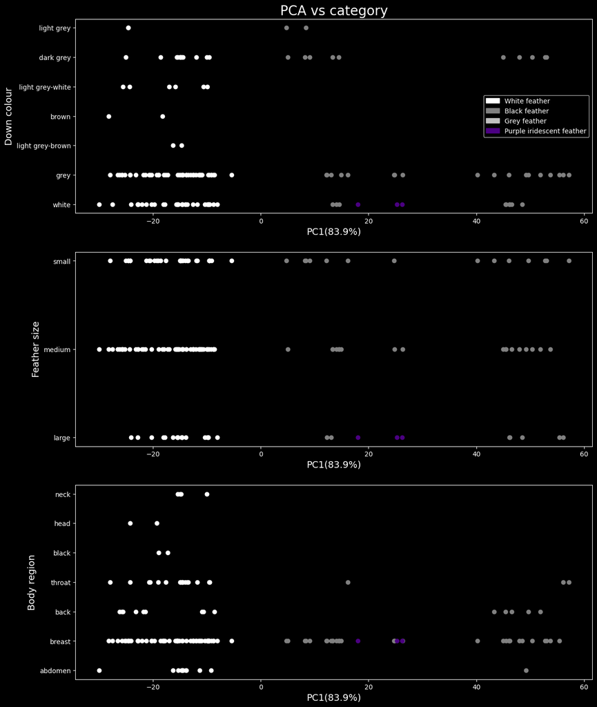

```python
features = {0:"Down colour", 1:"Feather size", 2:"Body region"}

fig, ax = plt.subplots(3,figsize=(14, 18))
for num in range(3):
    for c,p1,dscr in zip(colors,PC1, descr_df[features[num]].values):
        col = color_dict[c]
        ax[num].scatter(p1 ,dscr, color=col)
    ax[num].set_xlabel(f'PC1({pca.explained_variance_ratio_[0]*100:.3}%)', fontsize=14)
    ax[num].set_ylabel(f'{features[num]}', fontsize=14)


white_patch = mpatches.Patch(color='white', label='White feather')
black_patch = mpatches.Patch(color='grey', label='Black feather')
grey_patch = mpatches.Patch(color='silver', label='Grey feather')
purple_patch = mpatches.Patch(color='indigo', label='Purple iridescent feather')
ax[0].set_title('PCA vs category', fontsize=20)
ax[0].legend(handles=[white_patch,black_patch,grey_patch,purple_patch])

plt.show()
```

It's okay I guess but it does not provide us with any more data. There is not a distinct category that separates the two last groups confincing. Only if there was some information on microstructure of the feather or something.

### Now we will try to correlate parental length to their offspring in the Galton dataset

```python
galton_file = "galton.dat"
gal_df = pd.read_table(galton_file)
gal_df
```

|  | family | father | mother | gender | height | kids | male | female |
| --- | --- | --- | --- | --- | --- | --- | --- | --- |
| 0 | 1 | 78.5 | 67.0 | M | 73.2 | 4 | 1.0 | 0.0 |
| 1 | 1 | 78.5 | 67.0 | F | 69.2 | 4 | 0.0 | 1.0 |
| 2 | 1 | 78.5 | 67.0 | F | 69.0 | 4 | 0.0 | 1.0 |
| 3 | 1 | 78.5 | 67.0 | F | 69.0 | 4 | 0.0 | 1.0 |
| 4 | 2 | 75.5 | 66.5 | M | 73.5 | 4 | 1.0 | 0.0 |
| ... | ... | ... | ... | ... | ... | ... | ... | ... |
| 893 | 136A | 68.5 | 65.0 | M | 68.5 | 8 | 1.0 | 0.0 |
| 894 | 136A | 68.5 | 65.0 | M | 67.7 | 8 | 1.0 | 0.0 |
| 895 | 136A | 68.5 | 65.0 | F | 64.0 | 8 | 0.0 | 1.0 |
| 896 | 136A | 68.5 | 65.0 | F | 63.5 | 8 | 0.0 | 1.0 |
| 897 | 136A | 68.5 | 65.0 | F | 63.0 | 8 | 0.0 | 1.0 |

898 rows × 8 columns

In the data we have length father, length mother and eiher male or female. The best option for correlating these factors to the offspring's height will be: Multi-Linear Regression (MLR).

```python
from sklearn import linear_model

x = gal_df[['father','mother','male','female']]
y = gal_df['height']


# with sklearn
regr = linear_model.LinearRegression()
regr.fit(x, y)
score = regr.score(x,y)

print(f'constant:{regr.intercept_}\ncoeff:{regr.coef_}\naccuracy:{score*100:.03}%')
```

```
constant:17.95773567408137
coeff:[ 0.40597803  0.32149514  2.61297566 -2.61297566]
accuracy:64.0%
```

which means for offspring: ~y = 17.9577 + 0.40597803* h_father + 0.3215* h_mother + 2.613* is_male + -2.613* is_female

```python
def f(var_list):
    father = var_list[0]
    mother = var_list[1]
    male = var_list[2]
    female = var_list[3]
    const = 17.95773567408137
    y = father*0.40597803+mother*0.32149514+male*2.61297566+female*-2.61297566 + const
    return y

gal_df["estimated_height"] = [f(i) for i in x.values]

gal_df
```

|  | family | father | mother | gender | height | kids | male | female | estimated_height |
| --- | --- | --- | --- | --- | --- | --- | --- | --- | --- |
| 0 | 1 | 78.5 | 67.0 | M | 73.2 | 4 | 1.0 | 0.0 | 73.980161 |
| 1 | 1 | 78.5 | 67.0 | F | 69.2 | 4 | 0.0 | 1.0 | 68.754210 |
| 2 | 1 | 78.5 | 67.0 | F | 69.0 | 4 | 0.0 | 1.0 | 68.754210 |
| 3 | 1 | 78.5 | 67.0 | F | 69.0 | 4 | 0.0 | 1.0 | 68.754210 |
| 4 | 2 | 75.5 | 66.5 | M | 73.5 | 4 | 1.0 | 0.0 | 72.601479 |
| ... | ... | ... | ... | ... | ... | ... | ... | ... | ... |
| 893 | 136A | 68.5 | 65.0 | M | 68.5 | 8 | 1.0 | 0.0 | 69.277390 |
| 894 | 136A | 68.5 | 65.0 | M | 67.7 | 8 | 1.0 | 0.0 | 69.277390 |
| 895 | 136A | 68.5 | 65.0 | F | 64.0 | 8 | 0.0 | 1.0 | 64.051439 |
| 896 | 136A | 68.5 | 65.0 | F | 63.5 | 8 | 0.0 | 1.0 | 64.051439 |
| 897 | 136A | 68.5 | 65.0 | F | 63.0 | 8 | 0.0 | 1.0 | 64.051439 |

898 rows × 9 columns

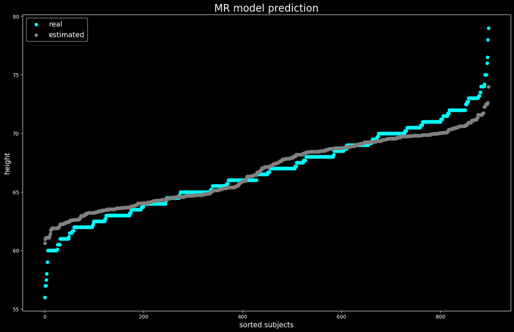

```python
#lets plot the result agains the real data

fig, ax = plt.subplots(layout='constrained', figsize=(14,9))
x = np.arange(898)
ax.scatter(x,sorted(gal_df['height']),color='cyan', label= 'real')
ax.scatter(x,sorted(gal_df['estimated_height']),color='grey', label='estimated')
ax.legend(fontsize=14)
ax.set_title("MR model prediction", fontsize=20)
ax.set_xlabel("sorted subjects",fontsize=14)
ax.set_ylabel("height", fontsize=14)
plt.show()
```

### Connectome data

brain connections in men and women, a 1 indicates a connection between the parts, 0 for none. Are there differences between men and women?

```python
# load the connectome data
connectome_file = "connectome_vectorized.csv.gz"
con_df = pd.read_csv(connectome_file)

con_df
```

|  | Unnamed: 0 | 0 | 1 | 2 | 3 | 4 | 5 | 6 | 7 | 8 | ... | 93139 | 93140 | 93141 | 93142 | 93143 | 93144 | 93145 | 93146 | 93147 | sex |
| --- | --- | --- | --- | --- | --- | --- | --- | --- | --- | --- | --- | --- | --- | --- | --- | --- | --- | --- | --- | --- | --- |
| 0 | 0 | 1 | 0 | 0 | 0 | 0 | 0 | 0 | 0 | 0 | ... | 0 | 0 | 1 | 0 | 0 | 1 | 0 | 0 | 0 | F |
| 1 | 1 | 0 | 0 | 0 | 0 | 1 | 0 | 1 | 0 | 0 | ... | 0 | 0 | 0 | 1 | 0 | 1 | 1 | 1 | 1 | M |
| 2 | 2 | 0 | 0 | 1 | 0 | 0 | 0 | 0 | 0 | 0 | ... | 0 | 0 | 0 | 0 | 0 | 1 | 0 | 0 | 1 | M |
| 3 | 3 | 0 | 0 | 0 | 0 | 1 | 0 | 1 | 0 | 0 | ... | 0 | 0 | 0 | 0 | 0 | 1 | 1 | 0 | 1 | M |
| 4 | 4 | 0 | 0 | 0 | 0 | 0 | 0 | 0 | 0 | 0 | ... | 0 | 0 | 0 | 0 | 0 | 1 | 1 | 0 | 1 | F |
| ... | ... | ... | ... | ... | ... | ... | ... | ... | ... | ... | ... | ... | ... | ... | ... | ... | ... | ... | ... | ... | ... |
| 91 | 91 | 0 | 0 | 0 | 0 | 0 | 0 | 0 | 0 | 0 | ... | 0 | 0 | 0 | 0 | 1 | 1 | 0 | 0 | 1 | M |
| 92 | 92 | 0 | 0 | 0 | 0 | 0 | 0 | 0 | 0 | 0 | ... | 0 | 0 | 0 | 0 | 0 | 1 | 0 | 0 | 1 | F |
| 93 | 93 | 0 | 0 | 1 | 0 | 1 | 0 | 0 | 0 | 0 | ... | 0 | 0 | 0 | 1 | 0 | 1 | 1 | 1 | 1 | F |
| 94 | 94 | 1 | 1 | 1 | 0 | 0 | 0 | 1 | 0 | 0 | ... | 0 | 0 | 0 | 0 | 0 | 1 | 1 | 1 | 1 | M |
| 95 | 95 | 0 | 0 | 0 | 0 | 1 | 0 | 0 | 0 | 0 | ... | 0 | 0 | 0 | 0 | 0 | 1 | 1 | 0 | 0 | F |

96 rows × 93150 columns

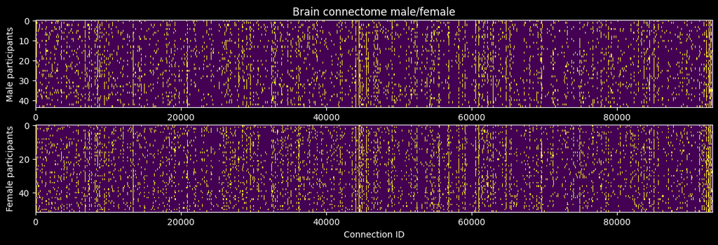

```python
# First lets plot the brain connectome to get an intuition for differences between men and women

fig, ax = plt.subplots(2,figsize=(14, 4))
ax[0].imshow(con_df[con_df['sex'] == 'M'].iloc[:,1:-1],interpolation='nearest',aspect='auto')
ax[1].imshow(con_df[con_df['sex'] == 'F'].iloc[:,1:-1],interpolation='nearest',aspect='auto')
ax[0].set_ylabel('Male participants')
ax[1].set_ylabel('Female participants')
ax[1].set_xlabel("Connection ID")
ax[0].set_title("Brain connectome male/female")
plt.show()
```

On first glance, no real difference can be seen between both connectomes

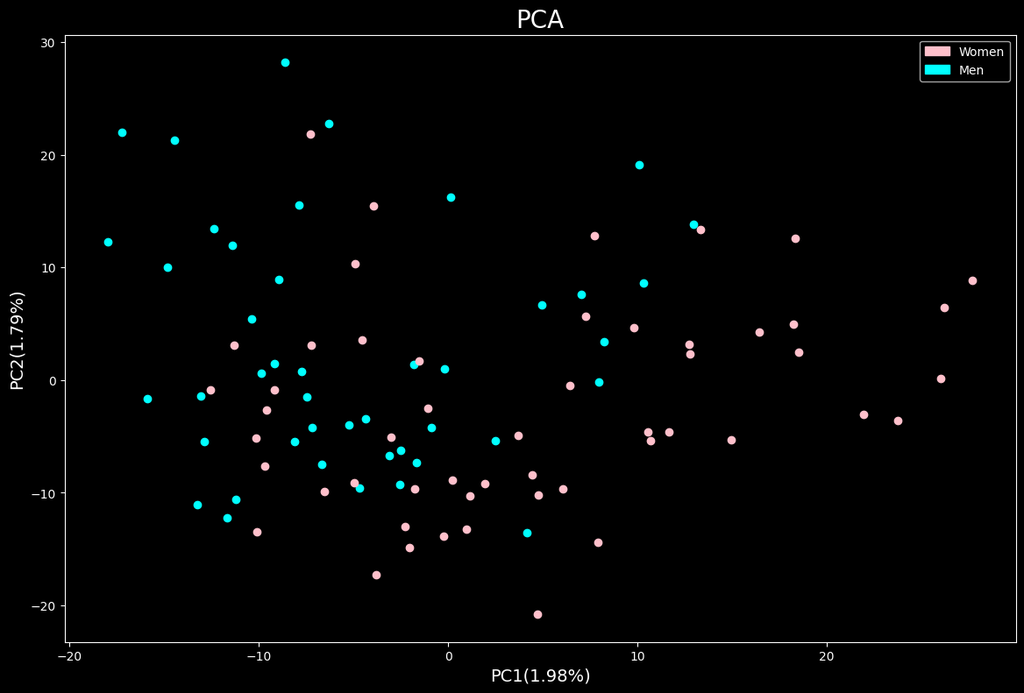

```python
con_pca = PCA()

colors = con_df['sex'].values
color_dict = {'F':'pink','M':'cyan'}

PC1 = con_pca.fit_transform(con_df.iloc[:,1:-1])[:,0]
PC2 = con_pca.fit_transform(con_df.iloc[:,1:-1])[:,1]


fig, ax = plt.subplots(figsize=(14, 9))
for c,p1,p2 in zip(colors,PC1,PC2):
    col = color_dict[c]
    ax.scatter(p1, p2, color=col)
pink_patch = mpatches.Patch(color='pink', label='Women')
cyan_patch = mpatches.Patch(color='cyan', label='Men')

ax.set_xlabel(f'PC1({con_pca.explained_variance_ratio_[0]*100:.3}%)', fontsize=14)
ax.set_ylabel(f'PC2({con_pca.explained_variance_ratio_[1]*100:.3}%)', fontsize=14)
ax.set_title('PCA', fontsize=20)
ax.legend(handles=[pink_patch,cyan_patch])

plt.show()
```

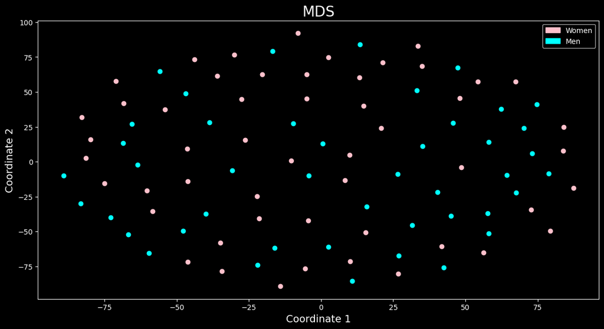

```python
#Job mentioned that Tsjerk mentioned that an MDS would be better suited here,

from sklearn.manifold import MDS

mds = MDS(normalized_stress='auto')
scaled_df = mds.fit_transform(con_df.iloc[:,1:-1])

CO1 = scaled_df[:,0]
CO2 = scaled_df[:,1]

fig, ax = plt.subplots(figsize=(14,7))

for c,c1,c2 in zip(colors,CO1,CO2):
    col = color_dict[c]
    ax.scatter(c1, c2, color=col)

pink_patch = mpatches.Patch(color='pink', label='Women')
cyan_patch = mpatches.Patch(color='cyan', label='Men')

ax.set_xlabel(f'Coordinate 1', fontsize=14)
ax.set_ylabel(f'Coordinate 2', fontsize=14)
ax.set_title('MDS', fontsize=20)
ax.legend(handles=[pink_patch,cyan_patch])

plt.show()
```